# Red Wine’s Qualities Exploration By CHEN XINRUI

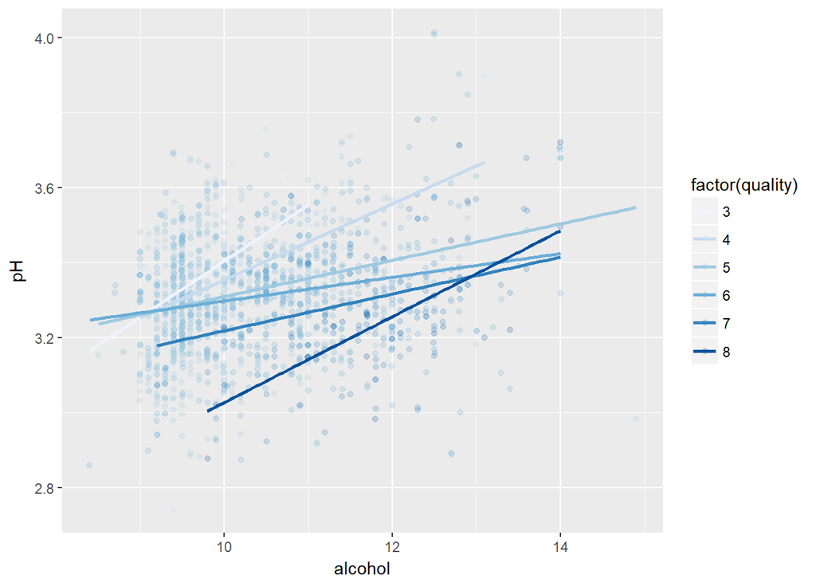

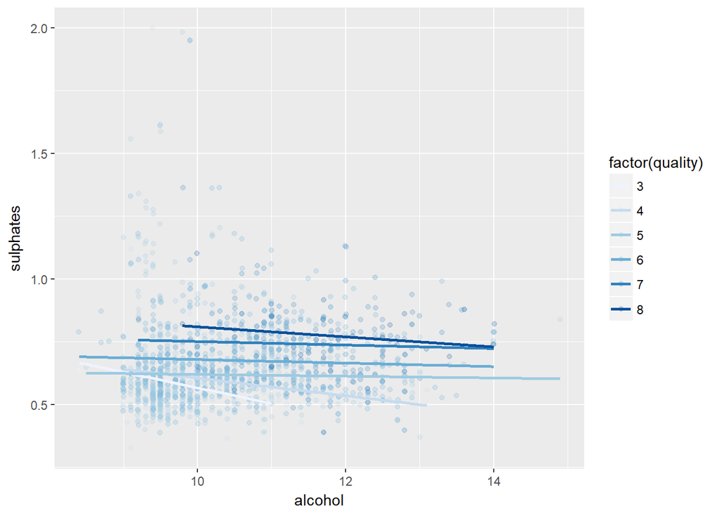

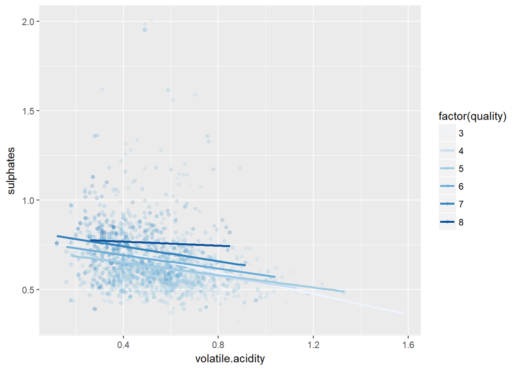

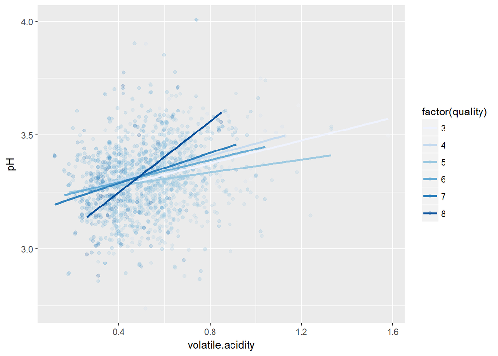

# Multivariate Analysis

### Talk about some of the relationships you observed in this part of the investigation. Were there features that strengthened each other in terms of looking at your feature(s) of interest?

Alcohol and volatile acidity strengthened each other, they both decide the quality.The third variable to join the final judgment seems to have little effect. Only one of the values is too large or too small, the score will be affected by this value.

### Were there any interesting or surprising interactions between features?

The correlation between other variables is not large, and at very high or very low levels of volatile acids and alcohols, the basic rating depends on both. Scores will be influenced by other factors only if both are centered. Therefore, the expert’s score may be based on the following clues, if the alcohol concentration and volatile acids when problems arise, will be directly based on these two factors to give a score, when these two factors are not too much of a problem, they will consider other Plus points and minus items.

### OPTIONAL: Did you create any models with your dataset? Discuss the strengths and limitations of your model.

No

# Final Plots and Summary

### Plot One

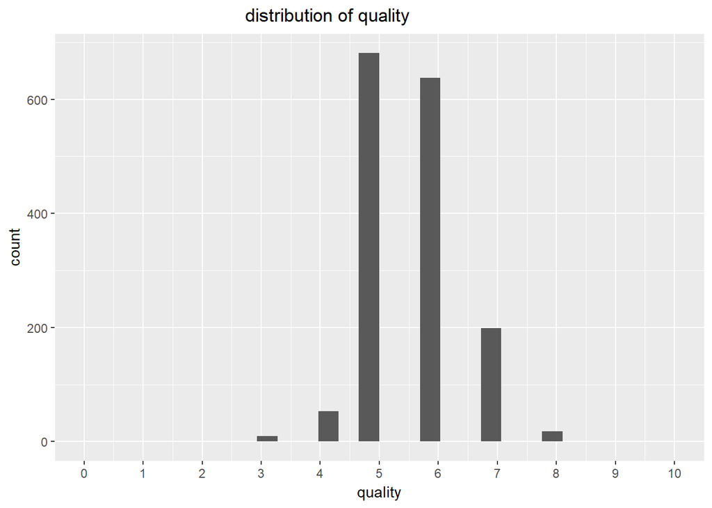

### Description One

Most of the scores are in the middle of 5 and 6, the relatively low and high scores are relatively small, expert ratings may be based on one or several features are particularly good or bad to add and subtract points, and Most of the wine does not have prominence.

### Plot Two

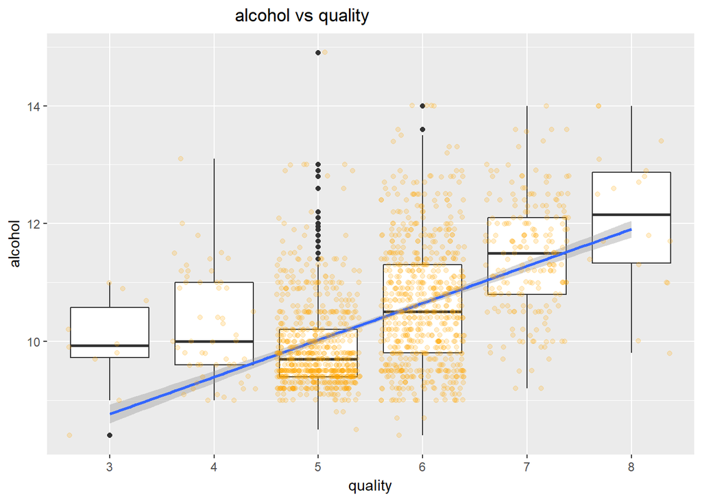

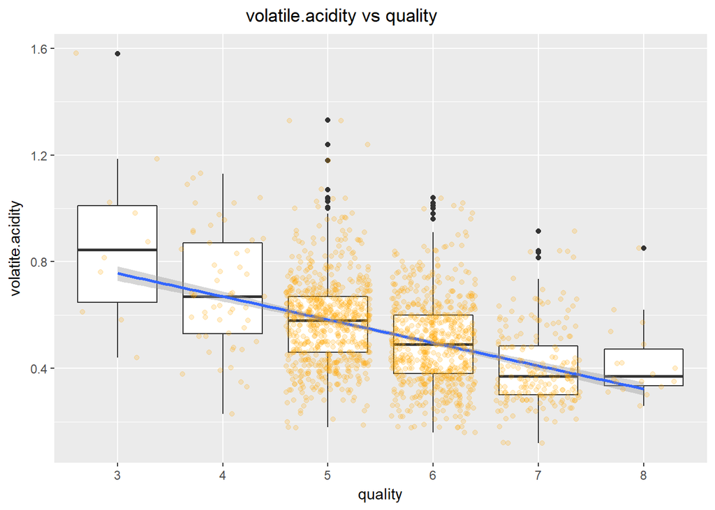

### Description Two

Red wine with higher quality has a higher alcohol concentration or lower volatile acids. Quality seems coorlate with alcohol and volatile acidity a lot. When volatile acidity level improves, the quality has a tendency to decrease.When alcohol level improves, the quality has a tendency to improve.

### Plot Three

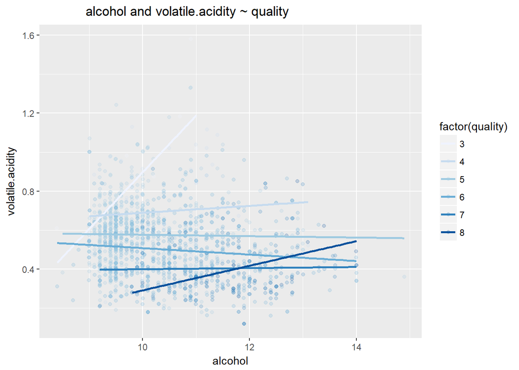

### Description Three

This figure shows that the impact of a single variable is far greater than the combined effect of two variables, only if the alcohol concentration is not low and the volatile acid is not high, the quality will be relatively good. When the alcohol concentration is low, the quality is not high regardless of the change of the volatile acid, and when the volatile acid is relatively high, the quality is not high regardless of the alcohol concentration. Only in both the better range, the quality will be better.Therefore, in the case of a large problem with a variable, the quality of the expert score will not change much regardless of other variables, so the logic of the expert score may be that when a variable is poor, regardless of other variables How good. Basically the score will not be too high, but only when the other variables are generally even exceptionally good, a variable is particularly good will make the score better.

# Reflection

Wine dataset includes 12 variables, 1599 bottles of red wine information. From the very beginning I conducted an analysis of each variable and then put together some of the variables and quality analysis. Finaly I analyze the relationship between the two variables and wine quality, trying to find the relevance.I find the variables that are highly correlated with the quality of the wine: volatile acids and alcohol.In order to find out the relationship between them, I plot the scatter plots and the fitting lines, and properly take the logarithm of the axes. Then, remove the abnormal point, find the correlation coefficient, and finally found the relationship. While working on relationships between multivariates, I found that there was no clear relationship regardless of the three variables, and then I thought that quality was a subjective evaluation, so I made the bold assumption that when a variable is poor , No matter how good the other variables are, basically the score is not too high, and a variable with a very good value will make the score better only if other variables are generally even exceptionally good. And the relationship shown in the diagram can also prove my hypothesis.In my future work, I will better explore the data set, if I can introduce new variables to explore from a new perspective.